# Quiz6_takehome

Clara Mugnai

2/28/2022

Complete this Quiz in a .Rmd file. Submit a .Rmd and a knitted .html file to GitHub by the due date and time.

“All work presented is my own, and I have followed all rules for collaboration.”

Clara Mugnai

Collaboration Reminder: You may work with other students who are in our class on the take-home quiz, but you must list who you worked with at the top of your quiz. Write the name of any student(s) that you collaborated with in the space below this (ignore this if you did not collaborate with any students). - worked with Grace Wysocki

Construct a Shiny app for any data set that we have worked with so far (besides SLU Majors and Tennis) or for any data set you used in STAT/DATA 234. Thirteen points will be given for Shiny apps that:

run, have at least 2 different inputs, have at least 1 plot output that looks presentable (e.g. appropriate labels, colour scale, and makes sense to construct). Then, write a 2 sentence description about the purpose of your app (2 points).

```r
library(tidyverse)
pokemon_df <- read_csv("data/pokemon_full.csv")
```

```
## * `` -> ...1
```

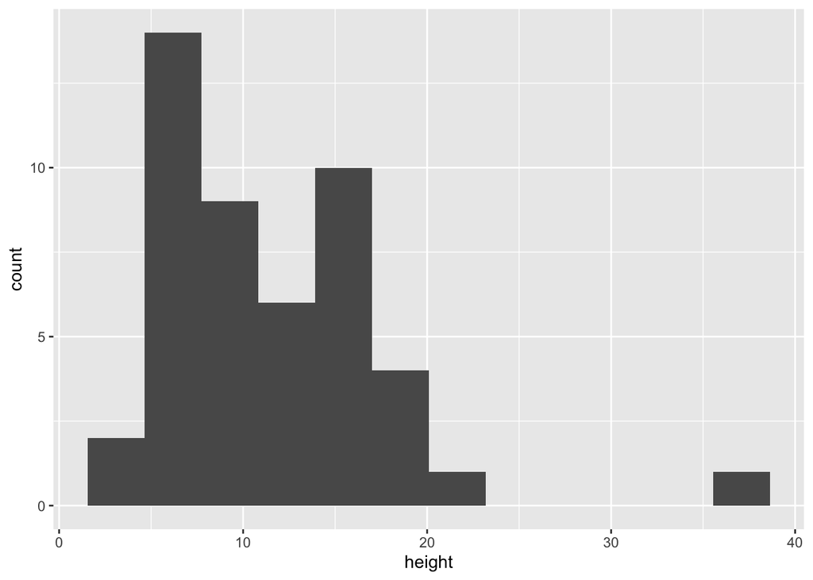

```r
library(shiny)

# making a shiny site that shows a histogram of pokemon weight/height/base experience for a specific type. The user picks type and the variable on the histogram.

df_onetype <- pokemon_df %>% filter(Type == "Fire")
ggplot(data = df_onetype, aes_string(x = "height")) + geom_histogram(bins = 12)
```

```r
ui <- fluidPage(
  sidebarLayout(sidebarPanel(
    selectizeInput("typechoice",
                   label = "Choose a Type of Pokemon", choices = levels(factor(pokemon_df$Type)),
                   selected = "Fire"),
    radioButtons("statchoice", label = "Choose a Statistic",
                 choices = names(pokemon_df)[c(12,13,14)])),
    mainPanel(plotOutput("histplot"))
  )
)

server <- function(input, output, session) {

  pokemon_small <- reactive({
    pokemon_df %>% filter(Type == input$typechoice)
  })

  output$histplot <- renderPlot({
ggplot(data = pokemon_small(), aes(x = .data[[input$statchoice]])) + geom_histogram(bins = 12, fill = "forestgreen", color = "purple")
  })

}

shinyApp(ui, server)
```

[output not shown]

Shiny applications not supported in static R Markdown documents

The purpose of this app is to give users a visual of the different distributions of height, weight, and base experience across different types of Pokemon. They get to choose a type and then a stat and see that, for example, electric pokemon are much lighter than rock pokemon.